# Slurm Basics

High Performance Computing (HPC) platforms generally use a job manager system to ensure equitable access to computing resources for multiple users. At Boise State University, the Borah computing cluster runs submitted SBATCH files that use slurm command line. In this section, we will breakdown slurm scripts and provide an example.

### 0.0.1 Slurm requirements

Slurm scripts have four parts:

1. **Shebang command** functions to interpret the UNIX commands and run the slurm script. This line of command is required at the top of every slurm script.

   `#!/bin/bash`
2. **Resource request section** breakdowns the amount of resources required for the job and informs slurm of the job name, RAM requirements, number of CPUs, nodes, and many other parameters explained below.

   `-J`: Name of the job specified by the user.

   `-o`: Output name of the sbatch which is generally the job name followed by `.o%j`.

   `-N`: Number of nodes specified for the job.

   `-n`: Number of CPU cores needed for tasks.

   `-t`: Run time limit for job.

   `--mail-type`: –mail-type is broken into `BEGIN` `END` and `FAIL`. These three lines function to notify the user when the job has started, ended, and/or failed.

   `--mail-user`: user email address is provided to receive job events specified above.
3. **Dependencies** details that software/modules that are required to run the job steps.

   `module load python`
4. **Job Step** details the module tasks required for the job.

[output not shown]

### 0.0.2 Slurm script example

Below is a slurm script example we will be using to download RNA-seq files to the computing cluster.

To make comments in a bash script, we use `##`

```
## Shebang
#!/bin/bash

## RESOURCE REQUEST
#SBATCH -J slurm_example #job name
#SBATCH -o log.o%j #log file output will be linked to the job number
#SBATCH -p bsudfq #CPU node request
#SBATCH -N 1 #One task specified
#SBATCH -n 14 #14 CPUs specified fort eh task
#SBATCH -t 14-00:00:00 #job maximum run time
#SBATCH --mail-type=END
#SBATCH --mail-type=BEGIN
#SBATCH --mail-type=FAIL
#SBATCH --mail-user=[insert unser EMAIL ADDRESS]

#########################
##DEPENDENCIES
# Load Modules:
module load bioinformatics/2023-05-04
module load sratoolkit/2.10.9

##JOB STEPS
# SRA toolkit:
fastq-dump -I --split-files SRR13279135
```

### 0.0.3 Creating and submitting a slurm file

It is recommended to write slurm scripts in a text editor and paste when you are ready to create a job file, copy and paste the content into the terminal. I recommend using [BBedit](https://www.barebones.com/products/bbedit/).

1. Log into Borah
2. Navigate to the scratch directory for your user `cd /scratch/username`
3. Create a directory for this practice example: `mkdir slurm_practice`
4. Navigate to the directory you just created: `cd slurm_practice`
5. Create a job file using the `nano` command: `nano slurm_example`
   - A text editor area will appear in the terminal (Figure 1). Paste a practice slurm script into the screen from your text editor.
   - You are welcome to use my example job file above, but be sure to insert your email address.

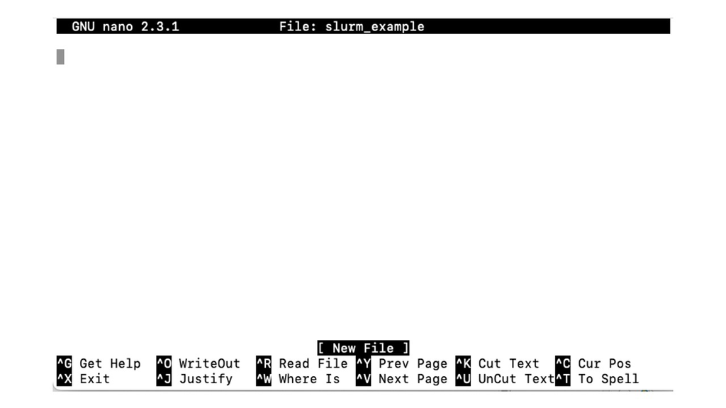

   Figure 1. Empty nano screen. Nano is a terminal based text editor.

   Job state codes
   - `PD - Pending`
   - `CG - Completing`
   - `CD - Completed`
   - `R - Running`
   - `F - Failed`
9. If you need to kill a job, use the following command: `scancel <jobid>`